# Worksheet 8

Published

November 5, 2025

Questions are below. My solutions will be available after the tutorials are all finished. The whole point of these worksheets is for you to use your lecture notes to figure out what to do. In tutorial, the TAs are available to guide you if you get stuck. Once you have figured out how to do this worksheet, you will be prepared to tackle the assignment that depends on it.

If you are not able to finish in an hour, I encourage you to continue later with what you were unable to finish in tutorial.

## Packages

```r
library(tidyverse)
library(smmr)
library(PMCMRplus)
```

## Hurricanes

The number of hurricanes making landfall on the east coast of the US was recorded each year from 1914 to 2014. The “hurricane season” is from June 1 to November 30 each year. The data are recorded in the file http://ritsokiguess.site/datafiles/hurricanes.csv. There are three columns: the year, the number of hurricanes, and `period`, in which the years are divided up into 25-year periods.

You might imagine that climate change may cause the number of hurricanes to have changed over time. One way to assess this is to divide the years into a number of groups (such as the 25-year periods here), and then to compare the number of hurricanes in each group. If the groups differ, there is some kind of trend over time.

1. Read in and display (some of) the data.

```r
my_url <- "http://ritsokiguess.site/datafiles/hurricanes.csv"
hurricanes <- read_csv(my_url)
hurricanes
```

| Year | Hurricanes | period |
| --- | --- | --- |
| 1914 | 0 | 1914 to 1939 |
| 1915 | 5 | 1914 to 1939 |
| 1916 | 10 | 1914 to 1939 |
| 1917 | 2 | 1914 to 1939 |
| 1918 | 4 | 1914 to 1939 |
| 1919 | 2 | 1914 to 1939 |
| 1920 | 4 | 1914 to 1939 |
| 1921 | 5 | 1914 to 1939 |
| 1922 | 3 | 1914 to 1939 |
| 1923 | 4 | 1914 to 1939 |

[output cut: 91 more lines]

The three columns as promised, along with one row per year.[^1]

`hurricanes` is actually a *inadvisable* name for the dataframe, because one of the columns in it is called `Hurricanes` with an uppercase H. It’s actually all right because R distinguishes uppercase names and lowercase ones, but it’s probably not a good idea to confuse yourself for no reason. Calling the dataframe `hurricane_counts` or `east_coast` or something like that would probably have been a better idea.

2. Make a suitable plot of the number of hurricanes by time *period*.

Even though `Year` is quantitative, time `period` is categorical, and the number of hurricanes is quantitative, so a boxplot is probably your first choice:

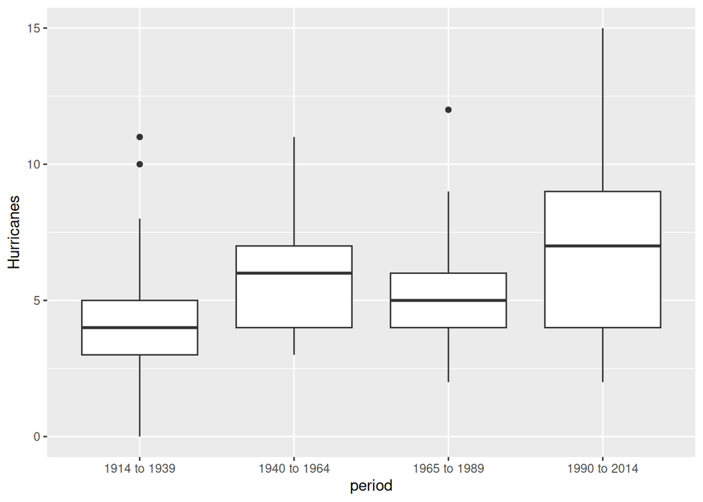

```r
ggplot(hurricanes, aes(x = period, y = Hurricanes)) + geom_boxplot()
```

As is often the case with these, reading ahead might convince you that *normality* is of interest, and for that reason, you might prefer a normal quantile plot here:

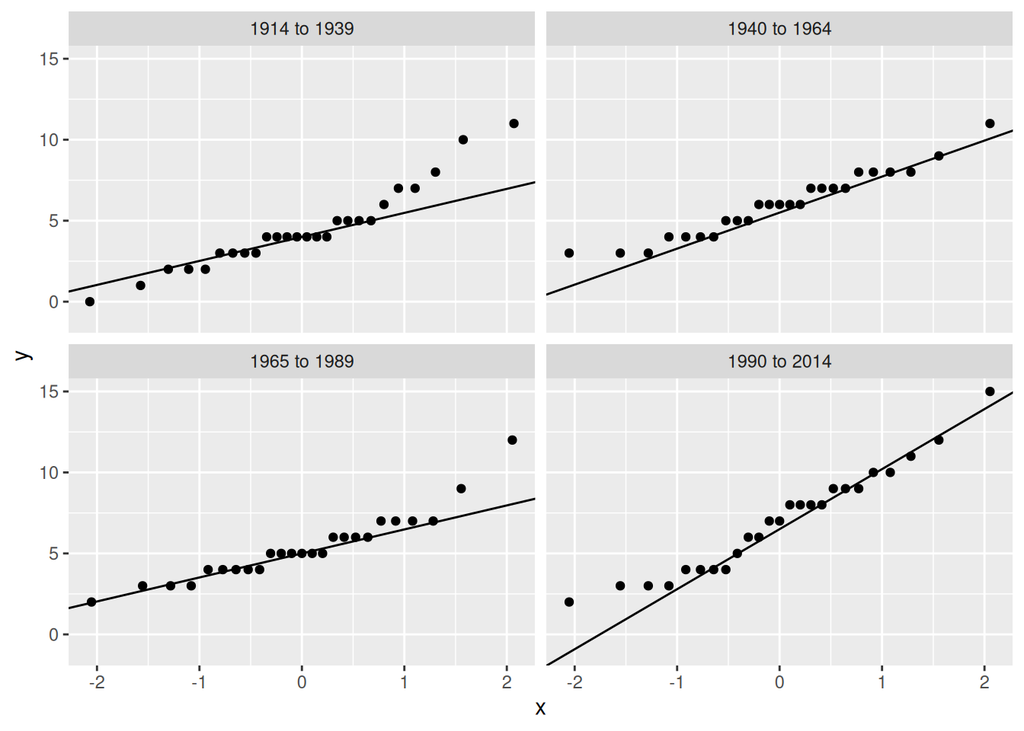

```r
ggplot(hurricanes, aes(sample = Hurricanes)) + stat_qq() +
  stat_qq_line() + facet_wrap(~ period)
```

If a normal quantile plot is your choice here, you should be ready to explain why you preferred that over a boxplot (something like “we will later need to assess normality of numbers of hurricanes within time periods” would do that).

Extra: Counts of things often have something like a [Poisson distribution](https://www.scribbr.com/statistics/poisson-distribution/). The variance of a Poisson distribution is the same as its mean, which would mean that a time period with more hurricanes (on average) would be expected to have a larger spread of hurricane counts, which seems to be what about has happened here. Counts have a lower limit of 0, so you might expect them to be skewed away from zero (that is, to the right).

3. Run a suitable analysis to compare the average numbers of hurricanes in the four time periods. Justify any choices you make. (That is to say, I am not telling you what kind of analysis to run; it is up to you to choose what *you* think is the best thing to do and to be able to say why you made the choice you did. My solutions to this question go into a fair bit of detail about what your considerations might be. If you want the practice, run all three possible kinds of analysis here, and then think about which one you prefer and why.)

This will be some kind of analysis of variance (to compare means or medians of four groups).

The first choice is which type of analysis to run: regular ANOVA, Welch ANOVA, Mood’s median test. To decide that, take a look at your plot to decide whether the distributions are normal enough given the sample sizes (25 or so). The Central Limit Theorem will help, so things will not be as bad as they look.

In summary, you need to have a *reason* for the analysis you do: something along one of these lines:

- The skewness or outliers are still too much of a problem (in at least one of the groups), and that therefore you should run Mood’s median test.
- Given the sample sizes, all the distributions are close enough to normal. Then, either:
  - the spreads are close enough to equal (the best argument for this is that the least tall boxes are also from the distributions with outliers, so these at least somewhat balance out; the boxes themselves are definitely not equal in height), therefore run a regular ANOVA.
  - the spreads are not close to equal (by comparing the heights of the boxes), therefore run a Welch ANOVA.

If you drew a normal quantile plot, you might argue that there are some outliers (or a long upper tail) in the 1914-1939 group and the 1965-1989 group, but given the sample sizes (25 in each group) this seems to be something the Central Limit Theorem ought to be able to take care of.[^2] As for equal spreads: I drew my plot *without* `scales = "free"`, so I can compare spreads by comparing the slopes of the lines; my take is that 1990-2014 seems definitely steeper (more spread out) than the others, so my take from there (yours can differ) is that I should run Welch in preference to a regular ANOVA.

Two points (when this was on an assignment) for making a properly reasoned call about the kind of analysis to run. I have no preference about your final choice, as long as your reason for making that choice is sound. (I think all three possible analyses are defensible, as long as you defend your choice properly.)

Then, running the analysis that you chose. One of these:

Mood median test:

```r
median_test(hurricanes, Hurricanes, period)
```

```
$grand_median
[1] 5

$table
              above
group          above below
  1914 to 1939     6    16
  1940 to 1964    15     7
  1965 to 1989    10     9
  1990 to 2014    16     8

$test
       what      value
1 statistic 9.67324773
2        df 3.00000000
3   P-value 0.02155796
```

The P-value of 0.0215 is less than 0.05, so the four time periods do not all have the same median number of hurricanes.[^3]

Welch ANOVA:

```r
oneway.test(Hurricanes ~ period, data = hurricanes)
```

```
    One-way analysis of means (not assuming equal variances)

data:  Hurricanes and period
F = 3.6079, num df = 3.0, denom df = 53.3, p-value = 0.01905
```

The P-value is in the same ballpark as the one for Mood’s median test (0.019), and again indicates that not all the time periods have the same mean number of hurricanes. Regular ANOVA:

```r
hurricanes.1 <- aov(Hurricanes ~ period, data = hurricanes)
summary(hurricanes.1)
```

```
            Df Sum Sq Mean Sq F value  Pr(>F)
period       3   87.3  29.088    4.52 0.00519 **
Residuals   97  624.2   6.435
---
Signif. codes:  0 '***' 0.001 '**' 0.01 '*' 0.05 '.' 0.1 ' ' 1
```

With a P-value of 0.0052, the time periods are not all the same in terms of mean number of hurricanes.

Two more points (when this was an assignment) for correctly running your chosen analysis and drawing an appropriate conclusion from it. The danger with this is to go too far here; all you can say is that the means/medians are not all equal.

The last two points were for running an appropriate followup given your choice of test. All three tests were significant, so you definitely need to run some sort of followup to determine which periods differed significantly from which in terms of average numbers of hurricanes.

If you ran Mood’s median test, pairwise median tests:

```r
pairwise_median_test(hurricanes, Hurricanes, period)
```

| g1 | g2 | p_value | adj_p_value |
| --- | --- | --- | --- |
| 1914 to 1939 | 1940 to 1964 | 0.006599418 | 0.03959651 |
| 1914 to 1939 | 1965 to 1989 | 0.096936316 | 0.58161789 |
| 1914 to 1939 | 1990 to 2014 | 0.007543954 | 0.04526372 |
| 1940 to 1964 | 1965 to 1989 | 0.157299207 | 0.94379524 |
| 1940 to 1964 | 1990 to 2014 | 0.474062736 | 1.00000000 |
| 1965 to 1989 | 1990 to 2014 | 0.031626423 | 0.18975854 |

Two of the comparisons are significant: the earliest time period 1914-1939 with the latest one 1990-2014, and with the *second* time period 1940-1964 (but not with the third one). None of the other differences are significant. What seems to have happened is that the 1914-1939 time period had an unusually *low* number of hurricanes. Remember to look at the adjusted (for multiple comparisons) P-values in the *last* column, so that the differences between the third and fourth time periods (in the last row) is *not* significant.

If you ran a Welch ANOVA, the appropriate followup is Games-Howell. I thought we had established that having a categorical variables that is text is fine (the help suggests that it should be), but you might end up with an error like this (scroll right to see the actual error):

```r
gamesHowellTest(Hurricanes ~ period, data = hurricanes)
```

```
Error in gamesHowellTest.default(c(0, 5, 10, 2, 4, 2, 4, 5, 3, 4, 5, 1, : all group levels must be finite
```

in which case you put `factor` around the categorical variable:

```r
gamesHowellTest(Hurricanes ~ factor(period), data = hurricanes)
```

```
    Pairwise comparisons using Games-Howell test
```

```
data: Hurricanes by factor(period)
```

```
             1914 to 1939 1940 to 1964 1965 to 1989
1940 to 1964 0.094        -            -
1965 to 1989 0.523        0.699        -
1990 to 2014 0.017        0.567        0.166
```

```
P value adjustment method: none
```

```
alternative hypothesis: two.sided
```

and then all will be good.

There is only one significant difference now, between the most recent and the oldest time periods. (The first and second time periods are no longer quite significantly different.)

If you ran regular ANOVA, Tukey’s method:

```r
TukeyHSD(hurricanes.1)
```

```
  Tukey multiple comparisons of means
    95% family-wise confidence level

Fit: aov(formula = Hurricanes ~ period, data = hurricanes)

$period
                                diff        lwr      upr     p adj
1940 to 1964-1914 to 1939  1.5384615 -0.3190830 3.396006 0.1404182
1965 to 1989-1914 to 1939  0.8984615 -0.9590830 2.756006 0.5876760
1990 to 2014-1914 to 1939  2.5384615  0.6809170 4.396006 0.0030575
1965 to 1989-1940 to 1964 -0.6400000 -2.5156674 1.235667 0.8090281
1990 to 2014-1940 to 1964  1.0000000 -0.8756674 2.875667 0.5063334
1990 to 2014-1965 to 1989  1.6400000 -0.2356674 3.515667 0.1084883
```

The only significant difference is between the first time period and the last one. None of the other differences are large enough to be significant. (This is the same conclusion as Games-Howell.)

If it so happens that your Mood median test/Welch/regular ANOVA was not significant, then you “do” the followup by explaining why you don’t need to do it (and thus get a rather cheap two points for the third thing).

So, three steps: a reasoned choice of which analysis to do, that analysis, and finally the appropriate followup for that analysis, with conclusions.

Extra 1: another option is to transform the data first in the hopes of getting distributions that are closer to normal. If you go this way, you need to say something about what inspired you to try it (since I haven’t talked about transformations yet), for example that in STAB27 (or your second course), you learned that a transformation of the response can be used to make the data within groups more nearly normal with more nearly equal spreads.[^4]

A transformation that is often useful for counts is the square root:

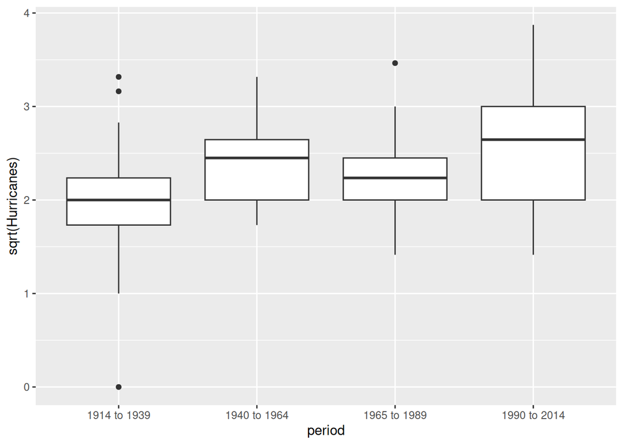

```r
ggplot(hurricanes, aes(x = period, y = sqrt(Hurricanes))) + geom_boxplot()
```

Normality is improved only a little, but maybe the spreads are closer to equal once you account for the outliers. If you are prepared to argue that normality and equal spreads are now good enough, you can run regular ANOVA:

```r
hurricanes.2 <- aov(sqrt(Hurricanes) ~ period, data = hurricanes)
summary(hurricanes.2)
```

```
            Df Sum Sq Mean Sq F value  Pr(>F)
period       3  4.432   1.477   4.828 0.00356 **
Residuals   97 29.683   0.306
---
Signif. codes:  0 '***' 0.001 '**' 0.01 '*' 0.05 '.' 0.1 ' ' 1
```

followed by Tukey:

```r
TukeyHSD(hurricanes.2)
```

```
  Tukey multiple comparisons of means
    95% family-wise confidence level

Fit: aov(formula = sqrt(Hurricanes) ~ period, data = hurricanes)

$period
                                diff          lwr       upr     p adj
1940 to 1964-1914 to 1939  0.4083197  0.003257533 0.8133818 0.0474176
1965 to 1989-1914 to 1939  0.2685875 -0.136474624 0.6736497 0.3121948
1990 to 2014-1914 to 1939  0.5668695  0.161807375 0.9719317 0.0022990
1965 to 1989-1940 to 1964 -0.1397322 -0.548746219 0.2692819 0.8084570
1990 to 2014-1940 to 1964  0.1585498 -0.250464221 0.5675639 0.7420358
1990 to 2014-1965 to 1989  0.2982820 -0.110732064 0.7072961 0.2321512
```

or, if you are OK with normality but not with equal spreads, Welch ANOVA, followed by Games-Howell:

```r
oneway.test(sqrt(Hurricanes) ~ period, data = hurricanes)
```

```
    One-way analysis of means (not assuming equal variances)

data:  sqrt(Hurricanes) and period
F = 3.6253, num df = 3.000, denom df = 53.137, p-value = 0.01869
```

```r
gamesHowellTest(sqrt(Hurricanes) ~ factor(period), data = hurricanes)
```

```
    Pairwise comparisons using Games-Howell test
```

```
data: sqrt(Hurricanes) by factor(period)
```

```
             1914 to 1939 1940 to 1964 1965 to 1989
1940 to 1964 0.058        -            -
1965 to 1989 0.340        0.661        -
1990 to 2014 0.016        0.722        0.225
```

```
P value adjustment method: none
```

```
alternative hypothesis: two.sided
```

In these cases, the first and last time periods differ significantly in mean numbers of hurricanes,[^5] and the first and second time periods are teetering on the brink when it comes to significance.

Aside: The reason for doing a transformation is to make your groups more normal with more equal spreads (one transformation will often do both), and so, if you find a transformation you are happy with, the analysis should be a regular or Welch ANOVA, not a Mood’s median test. In fact, if you do a Mood’s median test on the transformed data, you will get *exactly* the same result as you did before:

```r
median_test(hurricanes, sqrt(Hurricanes), period)
```

```
$grand_median
[1] 2.236068

$table
              above
group          above below
  1914 to 1939     6    16
  1940 to 1964    15     7
  1965 to 1989    10     9
  1990 to 2014    16     8

$test
       what      value
1 statistic 9.67324773
2        df 3.00000000
3   P-value 0.02155796
```

The reason is that the transformations we typically do (square root, log) keep the data values in the *same order* that they were before, so that (i) the median of the transformed values is the same as the transformed value of the median (read that carefully!),[^6] and (ii) all the values that were above the grand median before they were transformed will still be above the (transformed) median afterwards as well. Hence, the counts of aboves and belows, as well as the P-value, will be the same before and after transformation.

End of aside.

You might note that the P-values coming out of the analyses I did are all in the same ballpark, and the conclusions we draw are pretty much the same no matter which way I did it. This suggests that it actually didn’t matter much which analysis we did (see the next Extra for some more on this).

Extra 2: as always, when thinking about “normal enough”, you can do bootstrapped sampling distributions of the sample mean(s). The easiest approach is to pick the sample that you think is worst, and do that one. If it’s not good enough, the “sufficient normality” fails and Mood’s median test was the right one after all.[^7]

Outliers are usually more trouble than skewness, so let’s try the 1914-1939 time period. I’m going to draw a normal quantile plot of the results, so I’ll do 10,000 simulations:

```r
hurricanes %>% filter(period == "1914 to 1939") -> early
early
```

| Year | Hurricanes | period |
| --- | --- | --- |
| 1914 | 0 | 1914 to 1939 |
| 1915 | 5 | 1914 to 1939 |
| 1916 | 10 | 1914 to 1939 |
| 1917 | 2 | 1914 to 1939 |
| 1918 | 4 | 1914 to 1939 |
| 1919 | 2 | 1914 to 1939 |
| 1920 | 4 | 1914 to 1939 |
| 1921 | 5 | 1914 to 1939 |
| 1922 | 3 | 1914 to 1939 |
| 1923 | 4 | 1914 to 1939 |

[output cut: 16 more lines]

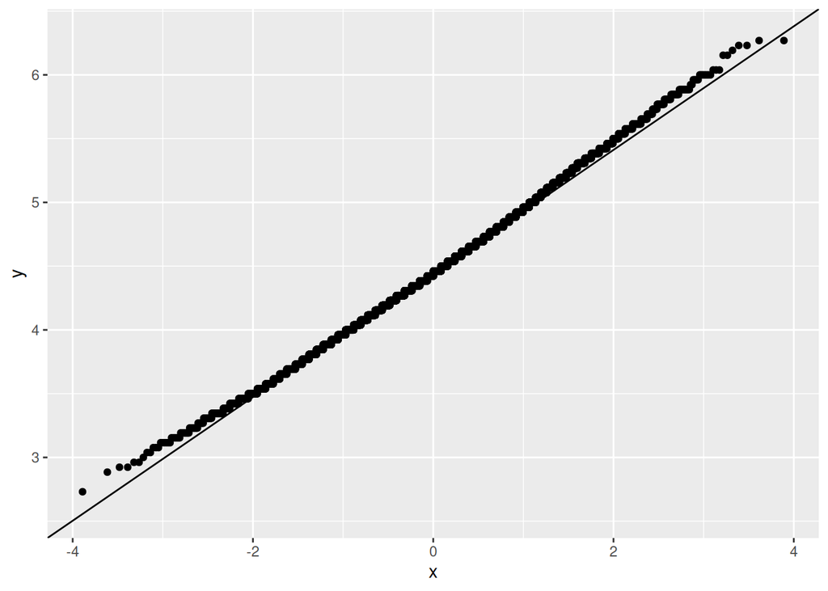

```r
tibble(sim = 1:10000) %>%
  rowwise() %>%
  mutate(my_sample = list(sample(early$Hurricanes, replace = TRUE))) %>%
  mutate(my_mean = mean(my_sample)) %>%
  ggplot(aes(sample = my_mean)) + stat_qq() + stat_qq_line()
```

That is actually pretty good, just a tiny bit right-skewed, but I would be perfectly happy with this. The message from here is that normality is fine (even in what I think is the worst case), so the Welch ANOVA is also fine.[^8]

You might have disagreed with me about the most non-normal group, so I should probably do all four of them, which I think I can do in one shot:

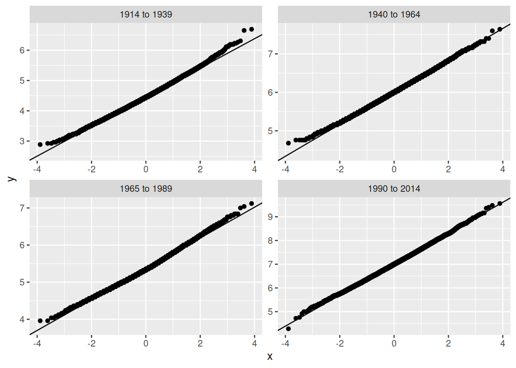

```r
hurricanes %>% nest_by(period) %>%
  rowwise() %>%
  mutate(sim = list(1:10000)) %>%
  unnest(sim) %>%
  rowwise() %>%
  mutate(my_sample = list(sample(data$Hurricanes, replace = TRUE))) %>%
  mutate(my_mean = mean(my_sample)) %>%
  ggplot(aes(sample = my_mean)) + stat_qq() + stat_qq_line() +
    facet_wrap(~ period, scales = "free")
```

It’s really hard to find much in the way of problems with any of those,[^9] so that the sample sizes of about 25 really *are* big enough to overcome the considerable non-normality of the data within each group. This, perhaps, ought to surprise you, but it goes to show just how powerful the Central Limit Theorem is.

The other worst one looks like 1965-1989, which is the other one with an outlier.[^10]

Hence, the “right” answer is to use Welch ANOVA because the four groups do differ in spread. But a well-argued case for one of the other tests is also full credit.

About my code above:

```r
hurricanes %>% nest_by(period)
```

| period | data |
| --- | --- |
| 1914 to 1939 | > |
| 1940 to 1964 | > |
| 1965 to 1989 | > |
| 1990 to 2014 | > |

What this does is to make a list-column containing dataframes with all the rows in `hurricanes` from the time period shown (thus, about 25 in each case), and all the columns from `hurricanes` *except* for the one I nested by (that is, only `Year` and `Hurricanes`). The advantage is that the things in `data` are exactly what I want to sample from in a minute.

```r
hurricanes %>% nest_by(period) %>%
  rowwise() %>%
  mutate(sim = list(1:3)) %>%
  unnest(sim)
```

| period | data | sim |
| --- | --- | --- |
| 1914 to 1939 | > | 1 |
| 1914 to 1939 | > | 2 |
| 1914 to 1939 | > | 3 |
| 1940 to 1964 | > | 1 |
| 1940 to 1964 | > | 2 |
| 1940 to 1964 | > | 3 |
| 1965 to 1989 | > | 1 |
| 1965 to 1989 | > | 2 |
| 1965 to 1989 | > | 3 |
| 1990 to 2014 | > | 1 |

[output cut: 2 more lines]

This makes a set of simulations for *each* time period. I showed you just three, instead of 10,000, so you could see how it worked.

Unnesting undoes `rowwise`, so now we have another `rowwise` followed by some code that looks very much like what we are used to. The differences are:

- each bootstrap sample needs to be of hurricane counts for just that time period, which is the column `Hurricanes` in the cut-down dataframe `data` each time.
- we need a separate normal quantile plot for each `period`, so we glue a `facet_wrap` onto the end.

Extra 3: if you can stand yet another Extra: you might have felt (reasonably) that dividing the `Year`s into four time periods was rather arbitrary. For one, choosing the number of periods is rather like choosing a number of bins on a histogram (and you might thus get different answers from different numbers of time periods), and for two, why make time categorical at all, when time is inherently quantitative? The reason I did it here was to give you an ANOVA question to do, but you will also see things like this done in environmental science. Sometimes they have a reason for dividing time up in this way (for example, 1990 is often taken as the start of perceptible climate change), but sometimes they do it for the same reason we did: to provide a comprehensible way to do analysis.

If you want to treat time as quantitative, the way to start is to *not* use `period` but to use the actual `Year`. This and `Hurricanes` are both quantitative, so the way to go is a scatterplot. This is really a “time plot”, with one observation per year, so the customary procedure is to join the points with lines:

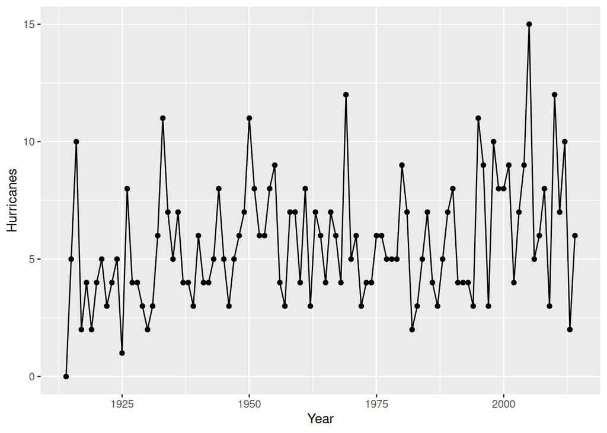

```r
ggplot(hurricanes, aes(x = Year, y = Hurricanes)) + geom_point() +
  geom_line()
```

This, as is often the case with data like these, has a lot of variability, but if anything there seems to be a slight upward trend. You could add a smooth trend to the plot, but then it seems to be clearer to take out the `geom_line`:

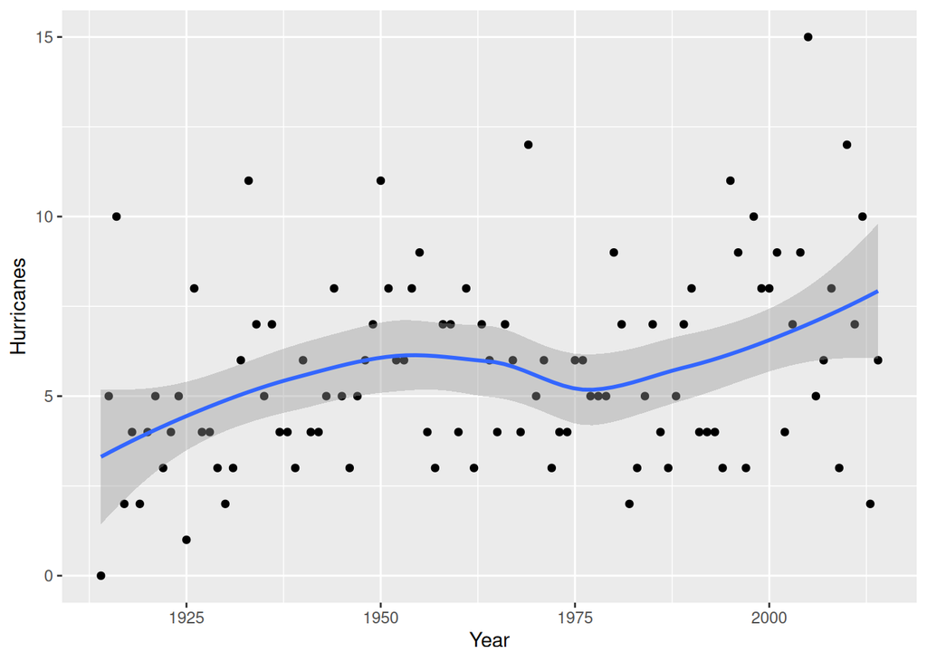

```r
ggplot(hurricanes, aes(x = Year, y = Hurricanes)) + geom_point() +
  geom_smooth()
```

The smooth trend seems to go up, down, up, but the width of the grey envelope suggests that the “down” in the middle may only be chance. The grey envelope at the end is definitely higher than at the beginning.

Remember that our conclusion from the ANOVAs was that there were more hurricanes on average recently than long ago. If you are willing to assume that the trend if any is linear,[^11] you can fit a regression with `Year`:[^12]

```r
hurr.1 <- lm(Hurricanes ~ Year, data = hurricanes)
summary(hurr.1)
```

```
Call:
lm(formula = Hurricanes ~ Year, data = hurricanes)

Residuals:
    Min      1Q  Median      3Q     Max
-5.0561 -1.8043 -0.1646  1.3347  8.1665

Coefficients:
              Estimate Std. Error t value Pr(>|t|)
(Intercept) -48.937472  17.112043  -2.860  0.00517 **
Year          0.027816   0.008712   3.193  0.00189 **
---
Signif. codes:  0 '***' 0.001 '**' 0.01 '*' 0.05 '.' 0.1 ' ' 1

Residual standard error: 2.553 on 99 degrees of freedom
Multiple R-squared:  0.09336,   Adjusted R-squared:  0.0842
F-statistic: 10.19 on 1 and 99 DF,  p-value: 0.001889
```

The R-squared is very low (because of the large amount of variability), but the slope (0.028 more hurricanes per year on average) is positive and significantly so (P-value 0.0019). So there really is an upward trend in the mean number of hurricanes over time. Also, 0.028 more hurricanes per year might not seem like much, but we have 100 years of data, so the increase over that timespan is predicted to be $0.028 \times 100 = 2.8$ hurricanes per year, and that starts to look meaningful.

That said, I’m not sure how good the assumption of a linear trend is. The time plot suggests that the number of hurricanes is low at the beginning, higher but constant in the middle, and higher still at the end: between about 1935 and 2000 there doesn’t seem to be much of an upward trend. The data are too variable to be sure about anything much.

## Bread

What makes bread rise? Specifically what are the effects of baking temperature and the amount of yeast on how much a loaf of bread will rise while baking? To find out, a batch of a certain bread mix was divided into 48 parts. Each part had a randomly chosen amount of yeast added (0.75, 1, or 1.25 teaspoons) and was then baked at a temperature of either 350 or 425 (degrees Fahrenheit). After baking, the height of each (very small) loaf of bread was measured (in inches). Apart from the yeast and the baking temperature, the ingredients for each small loaf were identical, so any differences in height can be attributed to one or both of the amount of yeast used and the baking temperature.

The data are in http://ritsokiguess.site/datafiles/bread_wide.csv.

4. Read in and display (most of) the data.

As usual:

```r
my_url <- "http://ritsokiguess.site/datafiles/bread_wide.csv"
bread <- read_csv(my_url)
bread
```

| row | yeast0.75_temp350 | yeast0.75_temp425 | yeast1_temp350 | yeast1_temp425 | yeast1.25_temp350 | yeast1.25_temp425 |
| --- | --- | --- | --- | --- | --- | --- |
| 1 | 1.3750 | 1.1875 | 1.4375 | 1.2500 | 1.7500 | 1.5000 |
| 2 | 1.2500 | 1.1250 | 1.5000 | 1.1250 | 1.8135 | 1.6250 |
| 3 | 1.2500 | 1.1870 | 1.5625 | 1.2500 | 1.7500 | 1.5625 |
| 4 | 1.1250 | 1.0000 | 1.7500 | 1.3125 | 1.8750 | 1.6875 |
| 5 | 1.3750 | 1.1250 | 1.7500 | 1.3750 | 1.7500 | 1.6250 |
| 6 | 1.1875 | 1.1875 | 1.4375 | 1.3125 | 1.9375 | 1.5000 |
| 7 | 1.2500 | 1.0625 | 1.5000 | 1.1875 | 1.8125 | 1.6250 |
| 8 | 1.3750 | 1.0625 | 1.6875 | 1.2500 | 1.7500 | 1.8125 |

There are only 8 rows, so you should see all of them and most of the columns. The column names are rather long, so you may not see all the columns.

5. The values in the dataframe are all values of height under various conditions (of yeast and temperature). Rearrange the dataframe so that you have one column of heights and one column of conditions.

This is your standard `pivot_longer`. Inputs are: the columns to rearrange (everything but row, or `starts_with("yeast")` or similar if you prefer). I gave you some clues about what you might call the new columns, but ultimately it is your choice:

```r
bread %>%
  pivot_longer(-row, names_to = "condition", values_to = "height")
```

| row | condition | height |
| --- | --- | --- |
| 1 | yeast0.75_temp350 | 1.3750 |
| 1 | yeast0.75_temp425 | 1.1875 |
| 1 | yeast1_temp350 | 1.4375 |
| 1 | yeast1_temp425 | 1.2500 |
| 1 | yeast1.25_temp350 | 1.7500 |
| 1 | yeast1.25_temp425 | 1.5000 |
| 2 | yeast0.75_temp350 | 1.2500 |
| 2 | yeast0.75_temp425 | 1.1250 |
| 2 | yeast1_temp350 | 1.5000 |
| 2 | yeast1_temp425 | 1.1250 |

[output cut: 38 more lines]

Now all the `height`s are in one column, labelled (next to them) by the treatment combination that produced that height. If you like, go through the original data and the rearranged data and convince yourself that the right things are still matched up.

It is sufficient to display the dataframe you have so far. We are going to do more with it and save it later.

6. The column containing the treatment conditions that you created in the previous question contains two things, amount of yeast and temperature. Create two new columns, each containing one of these. Hint: we saw `separate_wider_position` in lecture (in 2025, before reading week), which is not quite the right thing. If you have not seen it in lecture yet, investigate `separate_wider_delim`, for example [here](https://tidyr.tidyverse.org/reference/separate_wider_delim.html): scroll down to the bottom for examples, which you can copy and paste to see what they do.

This calls for some kind of `separate`, in particular `separate_wider_delim` because we want to make a dataframe that is wider than the one we have now, and the current column `condition` contains the two things we want separated (“delimited”) by something, namely an underscore. Join this onto the end of what you did previously:

```r
bread %>% pivot_longer(-row, names_to = "condition", values_to = "height") %>%
  separate_wider_delim(condition, "_", names = c("yeast", "temperature"))
```

| row | yeast | temperature | height |
| --- | --- | --- | --- |
| 1 | yeast0.75 | temp350 | 1.3750 |
| 1 | yeast0.75 | temp425 | 1.1875 |
| 1 | yeast1 | temp350 | 1.4375 |
| 1 | yeast1 | temp425 | 1.2500 |
| 1 | yeast1.25 | temp350 | 1.7500 |
| 1 | yeast1.25 | temp425 | 1.5000 |
| 2 | yeast0.75 | temp350 | 1.2500 |
| 2 | yeast0.75 | temp425 | 1.1250 |
| 2 | yeast1 | temp350 | 1.5000 |
| 2 | yeast1 | temp425 | 1.1250 |

[output cut: 38 more lines]

Now we have something we can use. You could save this, or you could use the idea in the next question.

7. Starting from the data you read in from the file, rearrange it so that there is one column of heights, and columns showing the amount of yeast and the temperature that goes with each height. Do your rearrangement with one command. Save your resulting dataframe. (Hint: if you are reading this during the 2025 reading week, we haven’t seen this in lecture yet.)

This is one of the variations of `pivot_longer`, in particular the one with two `names_to`, because you want a column of yeast amounts and a column of temperatures. The two parts of the (current) column names are separated by an underscore, so:

```r
bread %>% pivot_longer(-row, names_to = c("yeast", "temperature"),
                    names_sep = "_",
                    values_to = "height") -> bread_long
bread_long
```

| row | yeast | temperature | height |
| --- | --- | --- | --- |
| 1 | yeast0.75 | temp350 | 1.3750 |
| 1 | yeast0.75 | temp425 | 1.1875 |
| 1 | yeast1 | temp350 | 1.4375 |
| 1 | yeast1 | temp425 | 1.2500 |
| 1 | yeast1.25 | temp350 | 1.7500 |
| 1 | yeast1.25 | temp425 | 1.5000 |
| 2 | yeast0.75 | temp350 | 1.2500 |
| 2 | yeast0.75 | temp425 | 1.1250 |
| 2 | yeast1 | temp350 | 1.5000 |
| 2 | yeast1 | temp425 | 1.1250 |

[output cut: 38 more lines]

Just a (fancy) pivot-longer, nothing else. Compare the code here to your previous `pivot_longer`: the two things in `names_to`, and the `names_sep` to say what they are separated by. This runs an ordinary `pivot_longer` and the `separate_wider_delim` together, all in one shot.

8. Make a suitable graph of the three columns (not including `row`) in your tidied dataframe. (Hint: you can use either the dataframe you made in question 6 or the one from question 7 for this. It should work the same either way.)

These columns are `yeast`, `temperature`, and `height` (as I called them; use your own names), two categorical and one quantitative, so a grouped boxplot is called for. To make that, choose one of your categorical variables to be `x` and the other is `fill` (or `colour`); the quantitative variable is `y`:

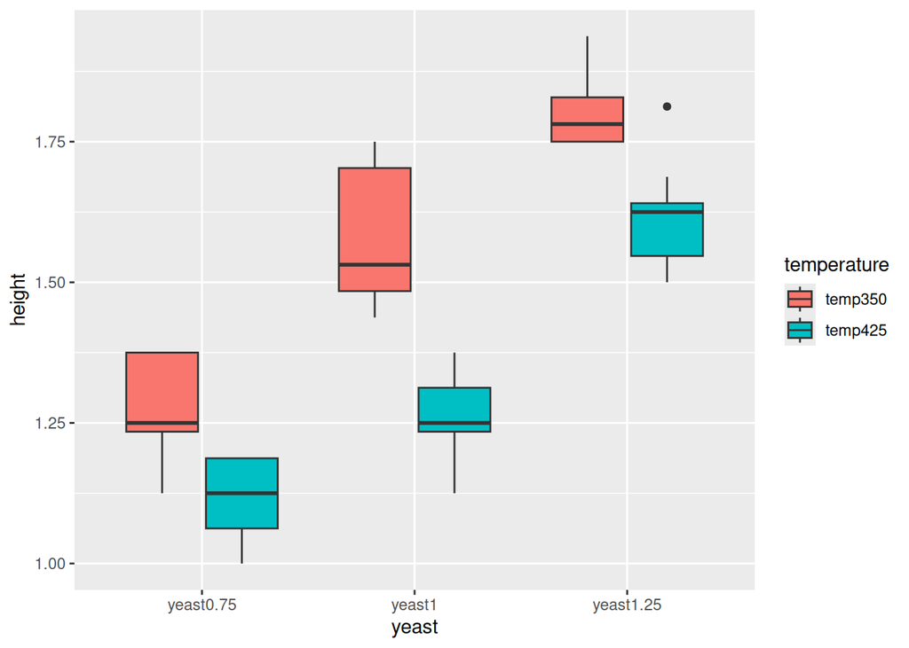

```r
ggplot(bread_long, aes(x = yeast, y = height, fill = temperature)) + geom_boxplot()
```

There are three different values of `yeast` and only two of `temperature`, so I put `yeast` on the $x$-axis. It seems better to me to make the best use of the “real-estate” on the $x$-axis: there is lots of room for categories there, but having more than a few colours is difficult to sort out. (The other consideration in deciding between `x` and `fill` is to put the response-like thing in `fill`, but here, both the categories are explanatory because they both influence `height`, so that is not a consideration here.)

Having said that, for this question (with only three and two categories), I have no objection if you have three colours:

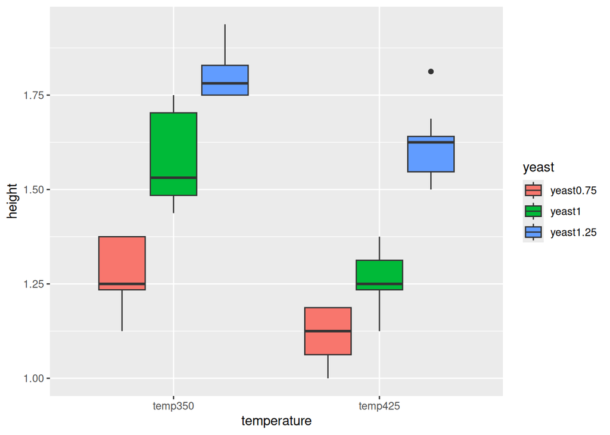

```r
ggplot(bread_long, aes(fill = yeast, y = height, x = temperature)) + geom_boxplot()
```

This graph was not so hard to draw once you had the data laid out properly. (This is often the case: most of the work is tidying the data.) I don’t think you could draw the graph at all with the data laid out as it originally was.

Extra: assuming that a bigger height is better, it is best to use more yeast and a *lower* temperature. The layout of the graphs suggests that a lower temperature is better for any amount of yeast, and more yeast is better at any temperature. That is to say, there is apparently no evidence of an *interaction* between temperature and yeast (if you think of this as an example of a two-way ANOVA). Further evidence of this is that the three sets of two graphs (or the two sets of three graphs, depending which way you drew it) are more or less parallel to each other, indicating that the effect of one variable does not depend on the level of the other one.

We look again at two-way ANOVAs in STAD29, but if you want to get a preview, it goes like this. First we fit a model with interaction, to allow for the possibility that `height` depends on the *combination* of `temperature` and `yeast`:

```r
bread.1 <- aov(height ~ temperature * yeast, data = bread_long)
summary(bread.1)
```

```
                  Df Sum Sq Mean Sq F value   Pr(>F)
temperature        1 0.5883  0.5883  66.681 3.29e-10 ***
yeast              2 2.1409  1.0705 121.331  < 2e-16 ***
temperature:yeast  2 0.0606  0.0303   3.437   0.0415 *
Residuals         42 0.3706  0.0088
---
Signif. codes:  0 '***' 0.001 '**' 0.01 '*' 0.05 '.' 0.1 ' ' 1
```

Rather surprisingly, the interaction term is just significant, so the *way* in which height depends on temperature is in fact different for each yeast (but possibly not very different, given that the interaction is only just significant).

The way I like to analyze things in the presence of a significant interaction is via “simple effects”: fix one of the explanatory variables, and look at the (one-way) effect of the other one. The way I just said it (“for each yeast”) says that what I have in mind is to look at the yeasts one at a time, and for each one assess the effect of temperature. This is consistent with my first grouped boxplot. Your preference might be along the lines of my second grouped boxplot instead (that is, for each *temperature*, compare the yeasts within that temperature). To do it my way, choose just the data you want (first `yeast0.75`) and then for just those data, assess the effect of temperature on height. Here’s `yeast0.75`:

```r
bread_long %>% filter(yeast == "yeast0.75") %>%
  aov(height ~ temperature, data = .) %>%
  summary()
```

```
            Df  Sum Sq Mean Sq F value Pr(>F)
temperature  1 0.09773 0.09773   14.16 0.0021 **
Residuals   14 0.09661 0.00690
---
Signif. codes:  0 '***' 0.001 '**' 0.01 '*' 0.05 '.' 0.1 ' ' 1
```

If it is clearer for you, save the result of the `filter` and then run `aov` the usual way. The `data = .` in my second line says “use the data from the previous step for the `aov` (that is, just the values for `yeast0.75`)”, and my third line says “run `summary` on the result of the previous step”.

There is a significant effect of temperature at this level of yeast, which we would guess from the grouped boxplot is because a lower temperature is associated with a larger height.

The other two levels of yeast go the same way:

```r
bread_long %>% filter(yeast == "yeast1") %>%
  aov(height ~ temperature, data = .) %>%
  summary()
```

```
            Df Sum Sq Mean Sq F value   Pr(>F)
temperature  1 0.4104  0.4104   34.71 3.92e-05 ***
Residuals   14 0.1655  0.0118
---
Signif. codes:  0 '***' 0.001 '**' 0.01 '*' 0.05 '.' 0.1 ' ' 1
```

```r
bread_long %>% filter(yeast == "yeast1.25") %>%
  aov(height ~ temperature, data = .) %>%
  summary()
```

```
            Df Sum Sq Mean Sq F value   Pr(>F)
temperature  1 0.1408 0.14081   18.18 0.000786 ***
Residuals   14 0.1084 0.00774
---
Signif. codes:  0 '***' 0.001 '**' 0.01 '*' 0.05 '.' 0.1 ' ' 1
```

So there is a significant temperature effect at all three levels of `yeast`, but the effect appears to be strongest for `yeast1` because the P-value is smallest. If you go back to the grouped boxplot, you’ll see that the difference in height for the two temperatures is noticeably bigger for `yeast1`, and presumably that was the reason that the interaction was (just) significant.

That said, this is one of the less impressive demonstrations of simple effects you will see, and you could get about as much understanding by pretending that the interaction was not significant, removing it, and then going with Tukey:

```r
bread.2 <- aov(height ~ temperature + yeast, data = bread_long)
summary(bread.2)
```

```
            Df Sum Sq Mean Sq F value   Pr(>F)
temperature  1 0.5883  0.5883   60.03 9.31e-10 ***
yeast        2 2.1409  1.0705  109.23  < 2e-16 ***
Residuals   44 0.4312  0.0098
---
Signif. codes:  0 '***' 0.001 '**' 0.01 '*' 0.05 '.' 0.1 ' ' 1
```

```r
TukeyHSD(bread.2)
```

```
  Tukey multiple comparisons of means
    95% family-wise confidence level

Fit: aov(formula = height ~ temperature + yeast, data = bread_long)

$temperature
                      diff        lwr        upr p adj
temp425-temp350 -0.2214167 -0.2790103 -0.1638231     0

$yeast
                         diff       lwr       upr p adj
yeast1-yeast0.75    0.2226875 0.1377961 0.3075789 3e-07
yeast1.25-yeast0.75 0.5157187 0.4308274 0.6006101 0e+00
yeast1.25-yeast1    0.2930313 0.2081399 0.3779226 0e+00
```

That is to say, the two temperatures differ significantly in terms of height, and all three yeasts differ in terms of height. Specifically, more yeast is better, and a lower temperature is better, in terms of increasing `height`. This seems in line with what the grouped boxplot is telling you.

Investigating the significant interaction gives you a more nuanced analysis, but possibly one that is *too* nuanced, given that the question of interest is probably something like “do either yeast or temperature make a difference to height?”. The analysis without the interaction gives a very clear answer of “yes, both of them do”.